# COSC-523: Lab 05

**Daniel Carter**

[Notebook Link](https://colab.research.google.com/drive/1aWg8_nRTi7GsHkkEa0xA2CwLXssqJFnf?usp=sharing)

## Getting Started

Follow the instructions below to copy this notebook and to perform some initial setup.

1. Copy this notebook by selecting `File > Save a copy in Drive`.
2. A new window should open for the copied notebook. Move the new notebook to your course folder in Google Drive by selecting `File > Move` and then selecting the desired folder.
3. Update the name of the notebook by removing "Copy of" and replacing "Username" with your actual username.
4. Update the first cell in the notebook by specifying your course number (423 or 523) and by replacing "**Student Name**" with your actual name.
5. Do not edit the line that says `PLACEHOLDER_FOR_NOTEBOOK_LINK`. This will be used by the [Notebook Renderer](https://colab.research.google.com/drive/1CJTipys46ldZxJFwnt7XbdjQUfkmoXeU?usp=sharing) tool to insert a link to your Colab notebook.
6. Enable link sharing for your notebook.

# Part 1: Understanding the Fundamentals of Neural Networks and CNNs

Instructions:

Answer the following questions as briefly as possible to understand the core concepts of Neural Networks and Convolutional Neural Networks:

- Explain the basic structure and components of a Neural Network, including neurons, layers, weights, and biases.
- What is the difference between a Fully Connected Neural Network (FNN) and a Convolutional Neural Network (CNN)?
- Describe the unique characteristics of CNNs, focusing on convolutional layers, pooling layers, and how they differ from traditional NNs.
- Explain the process of backpropagation and how it helps in optimizing the weights of a neural network during training.
- What is the purpose of activation functions in Neural Networks?
- Discuss the importance of activation functions such as ReLU, Sigmoid, and Tanh in introducing non-linearity to neural networks.
- Explain the basic structure and components of a Neural Network, including neurons, layers, weights, and biases.
  - The basic structure of a Neural Network is as follows
    - The inputs are the data points that are fed into the model
    - The weights are the resistances that are applied to the inputs
    - The neuron is the sum of all the weights. An activation function is applied to the neuron
    - Layers are the building block of neural networks. Models will have at least three, input, hinden, and output
    - Biases are the learnable parameters within the neuron
- What is the difference between a Fully Connected Neural Network (FNN) and a Convolutional Neural Network (CNN)?
  - The difference between a FNN and a CNN is that a fully connected neural network is built in such a way that the inputs are connected to the outputs. In a CNN, not all nodes are connected
- Describe the unique characteristics of CNNs, focusing on convolutional layers, pooling layers, and how they differ from traditional NNs.
  - The uique characteristics of CNNs are
    - convolutional layers apply the learnable filters to input data
    - pooling layers downsample feature maps to reduce spatial dimensions
    - They differ from traditional NNs because they are not fully connected
- Explain the process of backpropagation and how it helps in optimizing the weights of a neural network during training.
  - backpropagation is the process of adjusting the weights after an iteration of training to try to improve based on the previous iteration.
  - It helps in optimizing because as the wieghts are improved, the time it takes to train is reduced by the sped up learning process
- What is the purpose of activation functions in Neural Networks?
  - The purpose of the activation functions is to introduce non-linearity to the model to help it learn hierarchical features
- Discuss the importance of activation functions such as ReLU, Sigmoid, and Tanh in introducing non-linearity to neural networks.
  - The importance of activation functions introducing non-linearity is that it will allow the model to learn hierarchical features. They are able to ensure that the network is able to model complex patterns that linear transformations cannot do alone

# Part 2: Implementing a Simple CNN in Python Using Keras

Instructions:

- Similar to the Classification model we saw for the CIFAR dataset, we will create a CNN model, train it, and evaluate it on the MNIST dataset.
- Some of the initial code is gicen to you.
- Refer to the image "Lab 5 Part2" to look at the model summary and use that model summary to create your model exactly like the summary.
- Train the model for the a specific number of epochs, learning rate and evaluate its performance. Answer as a comment why did you specifically choose the epochs and learning rate value.

```
train_images.shape = (60000, 28, 28); train_labels.shape = (60000,)
test_images.shape = (10000, 28, 28); test_labels.shape = (10000,)
```

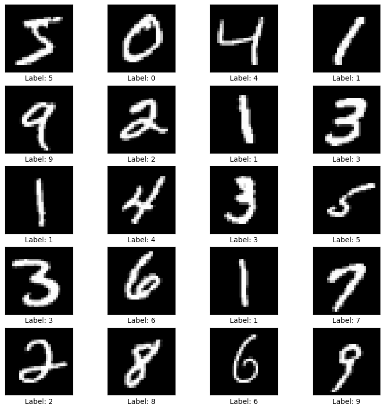

```python
import tensorflow as tf
from tensorflow.keras import datasets, layers, models
import numpy as np
import matplotlib.pyplot as plt
import random
import os
import seaborn as sns
import pandas as pd

# Fix the seed to reproduce results
SEED = 1001
os.environ['PYTHONHASHSEED'] = str(SEED)
os.environ['TF_CUDNN_DETERMINISTIC'] = '1'
random.seed(SEED)
np.random.seed(SEED)
tf.random.set_seed(SEED)

# Load MNIST dataset
(train_images, train_labels), (test_images, test_labels) = datasets.mnist.load_data()

# Print dataset shape
print(f'train_images.shape = {train_images.shape}; train_labels.shape = {train_labels.shape}')
print(f'test_images.shape = {test_images.shape}; test_labels.shape = {test_labels.shape}')

# Normalize pixel values to range [0, 1]
train_images = train_images / 255.0
test_images = test_images / 255.0

# Expand dimensions to add a channel (since MNIST images are grayscale)
train_images = np.expand_dims(train_images, axis=-1)
test_images = np.expand_dims(test_images, axis=-1)

# Display some images with their labels
plt.figure(figsize=(10, 10))
for i in range(20):
    plt.subplot(5, 4, i + 1)
    plt.xticks([])
    plt.yticks([])
    plt.imshow(train_images[i].squeeze(), cmap='gray')
    plt.xlabel(f"Label: {train_labels[i]}")
plt.show()
```

```
The image size = (28, 28, 1)
```

```
Model: "sequential"
```

```
┏━━━━━━━━━━━━━━━━━━━━━━━━━━━━━━━━━┳━━━━━━━━━━━━━━━━━━━━━━━━┳━━━━━━━━━━━━━━━┓
┃ Layer (type)                    ┃ Output Shape           ┃       Param # ┃
┡━━━━━━━━━━━━━━━━━━━━━━━━━━━━━━━━━╇━━━━━━━━━━━━━━━━━━━━━━━━╇━━━━━━━━━━━━━━━┩
│ conv2d (Conv2D)                 │ (None, 26, 26, 32)     │           320 │
├─────────────────────────────────┼────────────────────────┼───────────────┤
│ max_pooling2d (MaxPooling2D)    │ (None, 13, 13, 32)     │             0 │
├─────────────────────────────────┼────────────────────────┼───────────────┤
│ conv2d_1 (Conv2D)               │ (None, 11, 11, 64)     │        18,496 │
├─────────────────────────────────┼────────────────────────┼───────────────┤
│ max_pooling2d_1 (MaxPooling2D)  │ (None, 5, 5, 64)       │             0 │
├─────────────────────────────────┼────────────────────────┼───────────────┤
│ conv2d_2 (Conv2D)               │ (None, 3, 3, 64)       │        36,928 │
├─────────────────────────────────┼────────────────────────┼───────────────┤
│ flatten (Flatten)               │ (None, 576)            │             0 │
├─────────────────────────────────┼────────────────────────┼───────────────┤
│ dense (Dense)                   │ (None, 64)             │        36,928 │
├─────────────────────────────────┼────────────────────────┼───────────────┤
│ dropout (Dropout)               │ (None, 64)             │             0 │
├─────────────────────────────────┼────────────────────────┼───────────────┤
│ dense_1 (Dense)                 │ (None, 10)             │           650 │
└─────────────────────────────────┴────────────────────────┴───────────────┘
```

```
 Total params: 93,322 (364.54 KB)
```

```
 Trainable params: 93,322 (364.54 KB)
```

```
 Non-trainable params: 0 (0.00 B)
```

```
1875/1875 ━━━━━━━━━━━━━━━━━━━━ 15s 4ms/step - accuracy: 0.7240 - loss: 0.9519 - val_accuracy: 0.9617 - val_loss: 0.1336
1875/1875 ━━━━━━━━━━━━━━━━━━━━ 6s 3ms/step - accuracy: 0.9459 - loss: 0.1788 - val_accuracy: 0.9736 - val_loss: 0.0827
1875/1875 ━━━━━━━━━━━━━━━━━━━━ 8s 4ms/step - accuracy: 0.9647 - loss: 0.1199 - val_accuracy: 0.9818 - val_loss: 0.0619
1875/1875 ━━━━━━━━━━━━━━━━━━━━ 10s 4ms/step - accuracy: 0.9731 - loss: 0.0917 - val_accuracy: 0.9849 - val_loss: 0.0491
1875/1875 ━━━━━━━━━━━━━━━━━━━━ 10s 4ms/step - accuracy: 0.9775 - loss: 0.0754 - val_accuracy: 0.9855 - val_loss: 0.0448
1875/1875 ━━━━━━━━━━━━━━━━━━━━ 7s 4ms/step - accuracy: 0.9801 - loss: 0.0673 - val_accuracy: 0.9871 - val_loss: 0.0401
1875/1875 ━━━━━━━━━━━━━━━━━━━━ 8s 4ms/step - accuracy: 0.9824 - loss: 0.0587 - val_accuracy: 0.9871 - val_loss: 0.0382
1875/1875 ━━━━━━━━━━━━━━━━━━━━ 9s 4ms/step - accuracy: 0.9850 - loss: 0.0506 - val_accuracy: 0.9887 - val_loss: 0.0333
1875/1875 ━━━━━━━━━━━━━━━━━━━━ 11s 4ms/step - accuracy: 0.9861 - loss: 0.0454 - val_accuracy: 0.9897 - val_loss: 0.0314
1875/1875 ━━━━━━━━━━━━━━━━━━━━ 8s 4ms/step - accuracy: 0.9868 - loss: 0.0440 - val_accuracy: 0.9899 - val_loss: 0.0298
1875/1875 ━━━━━━━━━━━━━━━━━━━━ 7s 4ms/step - accuracy: 0.9884 - loss: 0.0383 - val_accuracy: 0.9901 - val_loss: 0.0301
1875/1875 ━━━━━━━━━━━━━━━━━━━━ 7s 4ms/step - accuracy: 0.9896 - loss: 0.0339 - val_accuracy: 0.9914 - val_loss: 0.0275
1875/1875 ━━━━━━━━━━━━━━━━━━━━ 9s 5ms/step - accuracy: 0.9901 - loss: 0.0324 - val_accuracy: 0.9897 - val_loss: 0.0288
1875/1875 ━━━━━━━━━━━━━━━━━━━━ 7s 4ms/step - accuracy: 0.9901 - loss: 0.0302 - val_accuracy: 0.9908 - val_loss: 0.0264
1875/1875 ━━━━━━━━━━━━━━━━━━━━ 7s 4ms/step - accuracy: 0.9912 - loss: 0.0296 - val_accuracy: 0.9913 - val_loss: 0.0284
The test loss = 0.028 and test accuracy = 0.991
```

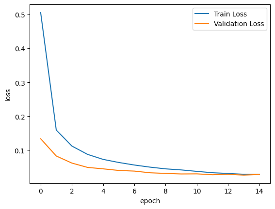

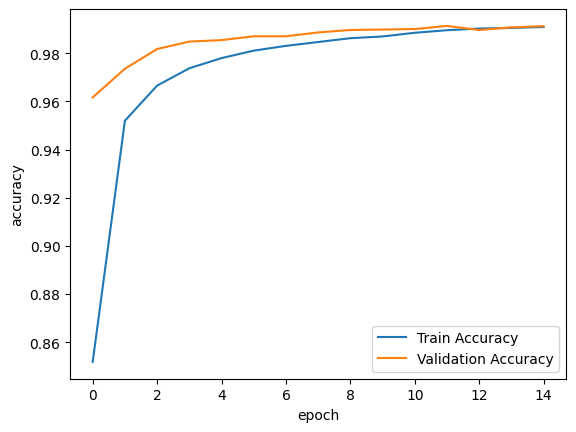

```python
# Define the CNN model
cnn_model = models.Sequential()

# Get the image size using the shape of train_images
image_size = train_images.shape
print(f'The image size = {image_size[1:]}')

# Add convolutional and pooling layers
cnn_model.add(layers.Conv2D(32, (3, 3), activation='relu', input_shape=image_size[1:]))
cnn_model.add(layers.MaxPooling2D((2, 2)))
cnn_model.add(layers.Conv2D(64, (3, 3), activation='relu'))
cnn_model.add(layers.MaxPooling2D((2, 2)))
cnn_model.add(layers.Conv2D(64, (3, 3), activation='relu'))

# Flatten the output and add Dense layers
cnn_model.add(layers.Flatten())
cnn_model.add(layers.Dense(64, activation='relu'))
cnn_model.add(layers.Dropout(0.2))
cnn_model.add(layers.Dense(10))

# Visualize the model architecture
cnn_model.summary()


# Compile the model
cnn_model.compile(optimizer=tf.keras.optimizers.Adam(learning_rate=0.0001),
                  loss=tf.keras.losses.SparseCategoricalCrossentropy(from_logits=True),
                  metrics=['accuracy'])

# Train the model
callback = tf.keras.callbacks.EarlyStopping(monitor='val_accuracy', patience=3)
history = cnn_model.fit(train_images, train_labels, epochs=20,
                        validation_data=(test_images, test_labels), callbacks=[callback], verbose=1)

# Evaluate the model
test_loss, test_acc = cnn_model.evaluate(test_images, test_labels, verbose=0)
print(f'The test loss = {np.round(test_loss, 3)} and test accuracy = {np.round(test_acc, 3)}')

# Plot training and validation loss
train_history = pd.DataFrame(history.history)
train_history['epoch'] = history.epoch
sns.lineplot(x='epoch', y='loss', data=train_history, label='Train Loss')
sns.lineplot(x='epoch', y='val_loss', data=train_history, label='Validation Loss')
plt.legend()
plt.show()

# Plot training and validation accuracy
sns.lineplot(x='epoch', y='accuracy', data=train_history, label='Train Accuracy')
sns.lineplot(x='epoch', y='val_accuracy', data=train_history, label='Validation Accuracy')
plt.legend()
plt.show()
```

# Part 3A: Debugging a CNN Part 1

Instructions:

- The code below is a siple CNN that distinguishes different species of flowers.
- This code runs with no errors however there is a huge mistake in it.
- Fix this error and mention in a comment what did you change to fix it!

```
Class names: ['dandelion', 'daisy', 'tulips', 'sunflowers', 'roses']
```

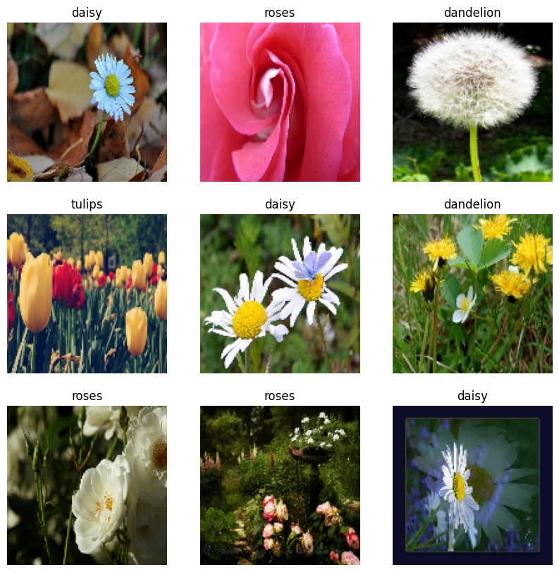

```
Model: "sequential_1"
```

```
┏━━━━━━━━━━━━━━━━━━━━━━━━━━━━━━━━━┳━━━━━━━━━━━━━━━━━━━━━━━━┳━━━━━━━━━━━━━━━┓
┃ Layer (type)                    ┃ Output Shape           ┃       Param # ┃
┡━━━━━━━━━━━━━━━━━━━━━━━━━━━━━━━━━╇━━━━━━━━━━━━━━━━━━━━━━━━╇━━━━━━━━━━━━━━━┩
│ conv2d_3 (Conv2D)               │ (None, 126, 126, 32)   │           896 │
├─────────────────────────────────┼────────────────────────┼───────────────┤
│ max_pooling2d_2 (MaxPooling2D)  │ (None, 63, 63, 32)     │             0 │
├─────────────────────────────────┼────────────────────────┼───────────────┤
│ conv2d_4 (Conv2D)               │ (None, 61, 61, 64)     │        18,496 │
├─────────────────────────────────┼────────────────────────┼───────────────┤
│ max_pooling2d_3 (MaxPooling2D)  │ (None, 30, 30, 64)     │             0 │
├─────────────────────────────────┼────────────────────────┼───────────────┤
│ conv2d_5 (Conv2D)               │ (None, 28, 28, 128)    │        73,856 │
├─────────────────────────────────┼────────────────────────┼───────────────┤
│ max_pooling2d_4 (MaxPooling2D)  │ (None, 14, 14, 128)    │             0 │
├─────────────────────────────────┼────────────────────────┼───────────────┤
│ flatten_1 (Flatten)             │ (None, 25088)          │             0 │
├─────────────────────────────────┼────────────────────────┼───────────────┤
│ dense_2 (Dense)                 │ (None, 128)            │     3,211,392 │
├─────────────────────────────────┼────────────────────────┼───────────────┤
│ dropout_1 (Dropout)             │ (None, 128)            │             0 │
├─────────────────────────────────┼────────────────────────┼───────────────┤
│ dense_3 (Dense)                 │ (None, 5)              │           645 │
└─────────────────────────────────┴────────────────────────┴───────────────┘
```

```
 Total params: 3,305,285 (12.61 MB)
```

```
 Trainable params: 3,305,285 (12.61 MB)
```

```
 Non-trainable params: 0 (0.00 B)
```

```
115/115 ━━━━━━━━━━━━━━━━━━━━ 14s 70ms/step - accuracy: 0.3425 - loss: 1.4583
115/115 ━━━━━━━━━━━━━━━━━━━━ 11s 18ms/step - accuracy: 0.5901 - loss: 1.0424
115/115 ━━━━━━━━━━━━━━━━━━━━ 2s 18ms/step - accuracy: 0.6351 - loss: 0.9193
115/115 ━━━━━━━━━━━━━━━━━━━━ 2s 17ms/step - accuracy: 0.7011 - loss: 0.7873
115/115 ━━━━━━━━━━━━━━━━━━━━ 2s 17ms/step - accuracy: 0.7572 - loss: 0.6437
115/115 ━━━━━━━━━━━━━━━━━━━━ 3s 20ms/step - accuracy: 0.8074 - loss: 0.4913
115/115 ━━━━━━━━━━━━━━━━━━━━ 5s 18ms/step - accuracy: 0.8409 - loss: 0.4149
115/115 ━━━━━━━━━━━━━━━━━━━━ 2s 17ms/step - accuracy: 0.9031 - loss: 0.2730
115/115 ━━━━━━━━━━━━━━━━━━━━ 3s 17ms/step - accuracy: 0.9339 - loss: 0.2058
115/115 ━━━━━━━━━━━━━━━━━━━━ 2s 19ms/step - accuracy: 0.9622 - loss: 0.1182
```

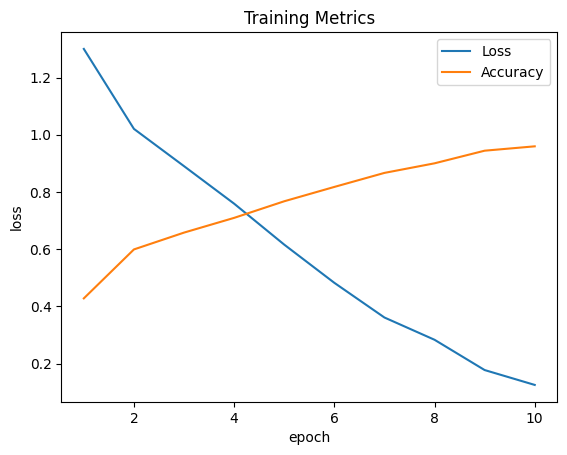

```python
import tensorflow as tf
import tensorflow_datasets as tfds
from tensorflow.keras import layers, models
import numpy as np
import matplotlib.pyplot as plt
import seaborn as sns
import pandas as pd
import os

# Fix the seed for reproducibility
SEED = 42
os.environ['PYTHONHASHSEED'] = str(SEED)
tf.random.set_seed(SEED)

# Load the Flowers dataset
dataset, info = tfds.load('tf_flowers', as_supervised=True, with_info=True)
train_dataset = dataset['train']

# Retrieve class names
class_names = info.features['label'].names
print(f"Class names: {class_names}")

# Define a preprocessing function for normalization and resizing
IMG_SIZE = 128

def preprocess_image(image, label):
    image = tf.image.resize(image, (IMG_SIZE, IMG_SIZE))
    image = tf.cast(image, tf.float32) / 255.0  # Normalize pixel values
    return image, label

# Apply preprocessing and split the data
train_dataset = train_dataset.map(preprocess_image)
train_dataset = train_dataset.shuffle(buffer_size=1000).batch(32).prefetch(tf.data.AUTOTUNE)

# Visualize some images from the dataset
plt.figure(figsize=(10, 10))
for i, (image, label) in enumerate(train_dataset.take(9)):
    plt.subplot(3, 3, i + 1)
    plt.imshow(image[0])
    plt.title(class_names[label[0].numpy()])
    plt.axis("off")
plt.show()

# Define the CNN model
model = models.Sequential([
    layers.Conv2D(32, (3, 3), activation='relu', input_shape=(IMG_SIZE, IMG_SIZE, 3)),
    layers.MaxPooling2D((2, 2)),
    layers.Conv2D(64, (3, 3), activation='relu'),
    layers.MaxPooling2D((2, 2)),
    layers.Conv2D(128, (3, 3), activation='relu'),
    layers.MaxPooling2D((2, 2)),
    layers.Flatten(),
    layers.Dense(128, activation='relu'),
    layers.Dropout(0.3),
    layers.Dense(5)
])

model.summary()

# Compile the model
model.compile(optimizer=tf.keras.optimizers.Adam(learning_rate=0.001),
              loss=tf.keras.losses.SparseCategoricalCrossentropy(from_logits=True),
              metrics=['accuracy'])

# Train the model
history = model.fit(train_dataset, epochs=10, verbose=1)

# Plot training metrics
history_df = pd.DataFrame(history.history)
history_df['epoch'] = range(1, len(history.epoch) + 1)

sns.lineplot(x='epoch', y='loss', data=history_df, label='Loss')
sns.lineplot(x='epoch', y='accuracy', data=history_df, label='Accuracy')
plt.title('Training Metrics')
plt.legend()
plt.show()
```

# One major error that I saw was that the output layer originally had 10. However, from the code that displays the labels, there are only 5 labels which means we need to adjust the last layer to only have 5

# Part 3B: Debugging a CNN Part 2

Instructions:

The code shown below is a CNN for classifying the Fashion MNIST dataset which is a dataset for different types of clothing.  
This code has 1 syntactical and 4 logical errors. Please fix them and identify them with a comment wherever you make the fix!

```
train_images.shape = (60000, 28, 28); train_labels.shape = (60000,)
test_images.shape = (10000, 28, 28); test_labels.shape = (10000,)
```

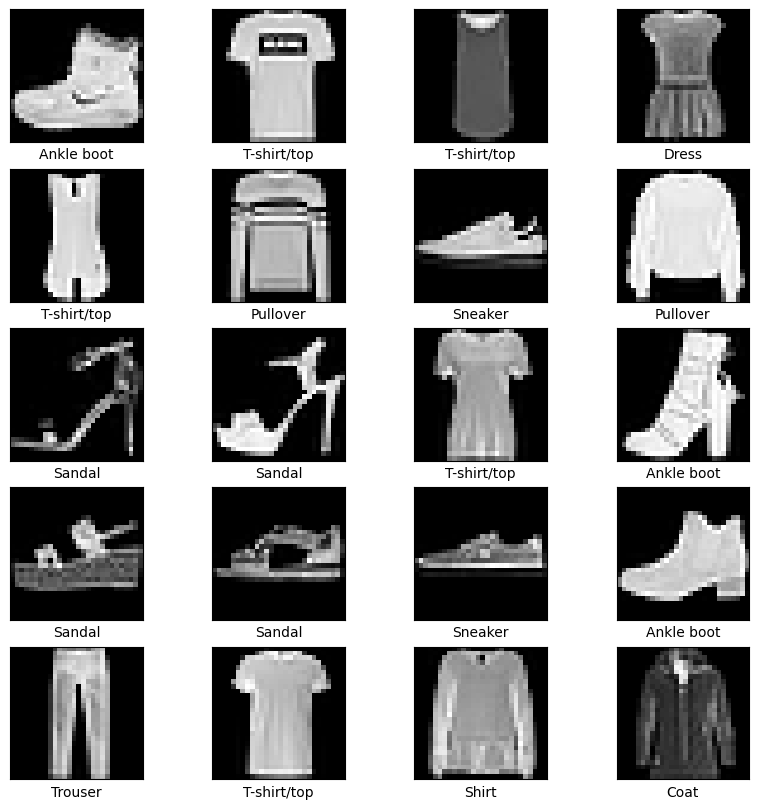

```
The input shape = (28, 28, 1)
```

```
Model: "sequential_2"
```

```
┏━━━━━━━━━━━━━━━━━━━━━━━━━━━━━━━━━┳━━━━━━━━━━━━━━━━━━━━━━━━┳━━━━━━━━━━━━━━━┓
┃ Layer (type)                    ┃ Output Shape           ┃       Param # ┃
┡━━━━━━━━━━━━━━━━━━━━━━━━━━━━━━━━━╇━━━━━━━━━━━━━━━━━━━━━━━━╇━━━━━━━━━━━━━━━┩
│ conv2d_6 (Conv2D)               │ (None, 26, 26, 32)     │           320 │
├─────────────────────────────────┼────────────────────────┼───────────────┤
│ max_pooling2d_5 (MaxPooling2D)  │ (None, 13, 13, 32)     │             0 │
├─────────────────────────────────┼────────────────────────┼───────────────┤
│ conv2d_7 (Conv2D)               │ (None, 11, 11, 64)     │        18,496 │
├─────────────────────────────────┼────────────────────────┼───────────────┤
│ max_pooling2d_6 (MaxPooling2D)  │ (None, 5, 5, 64)       │             0 │
├─────────────────────────────────┼────────────────────────┼───────────────┤
│ conv2d_8 (Conv2D)               │ (None, 3, 3, 64)       │        36,928 │
├─────────────────────────────────┼────────────────────────┼───────────────┤
│ flatten_2 (Flatten)             │ (None, 576)            │             0 │
├─────────────────────────────────┼────────────────────────┼───────────────┤
│ dense_4 (Dense)                 │ (None, 128)            │        73,856 │
├─────────────────────────────────┼────────────────────────┼───────────────┤
│ dropout_2 (Dropout)             │ (None, 128)            │             0 │
├─────────────────────────────────┼────────────────────────┼───────────────┤
│ dense_5 (Dense)                 │ (None, 10)             │         1,290 │
└─────────────────────────────────┴────────────────────────┴───────────────┘
```

```
 Total params: 130,890 (511.29 KB)
```

```
 Trainable params: 130,890 (511.29 KB)
```

```
 Non-trainable params: 0 (0.00 B)
```

```
1875/1875 ━━━━━━━━━━━━━━━━━━━━ 12s 5ms/step - accuracy: 0.6079 - loss: 1.1294 - val_accuracy: 0.7855 - val_loss: 0.5647
1875/1875 ━━━━━━━━━━━━━━━━━━━━ 7s 4ms/step - accuracy: 0.7878 - loss: 0.5676 - val_accuracy: 0.8218 - val_loss: 0.4814
1875/1875 ━━━━━━━━━━━━━━━━━━━━ 10s 4ms/step - accuracy: 0.8226 - loss: 0.4844 - val_accuracy: 0.8378 - val_loss: 0.4367
1875/1875 ━━━━━━━━━━━━━━━━━━━━ 11s 4ms/step - accuracy: 0.8432 - loss: 0.4342 - val_accuracy: 0.8504 - val_loss: 0.4031
1875/1875 ━━━━━━━━━━━━━━━━━━━━ 7s 4ms/step - accuracy: 0.8565 - loss: 0.3992 - val_accuracy: 0.8588 - val_loss: 0.3808
1875/1875 ━━━━━━━━━━━━━━━━━━━━ 7s 4ms/step - accuracy: 0.8629 - loss: 0.3769 - val_accuracy: 0.8678 - val_loss: 0.3600
1875/1875 ━━━━━━━━━━━━━━━━━━━━ 10s 4ms/step - accuracy: 0.8716 - loss: 0.3550 - val_accuracy: 0.8723 - val_loss: 0.3487
1875/1875 ━━━━━━━━━━━━━━━━━━━━ 7s 4ms/step - accuracy: 0.8779 - loss: 0.3382 - val_accuracy: 0.8761 - val_loss: 0.3383
1875/1875 ━━━━━━━━━━━━━━━━━━━━ 10s 4ms/step - accuracy: 0.8812 - loss: 0.3248 - val_accuracy: 0.8826 - val_loss: 0.3268
1875/1875 ━━━━━━━━━━━━━━━━━━━━ 7s 4ms/step - accuracy: 0.8869 - loss: 0.3113 - val_accuracy: 0.8857 - val_loss: 0.3118
The test loss = 0.31 and test accuracy = 0.89
```

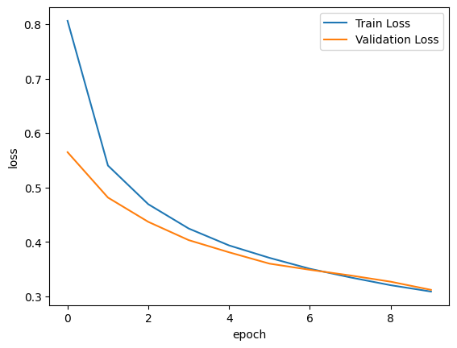

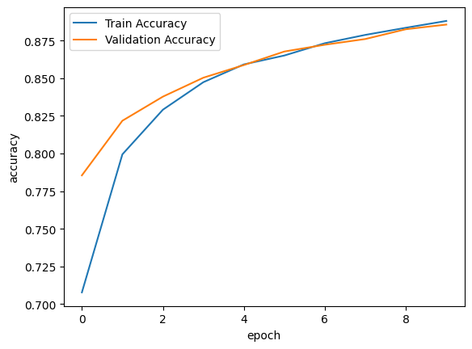

```python
import tensorflow as tf
from tensorflow.keras import datasets, layers, models
import numpy as np
import matplotlib.pyplot as plt
import seaborn as sns
import pandas as pd
import random
import os

# Fix the seed for reproducibility
SEED = 1001
os.environ['PYTHONHASHSEED'] = str(SEED)
os.environ['TF_CUDNN_DETERMINISTIC'] = '1'
random.seed(SEED)
np.random.seed(SEED)
tf.random.set_seed(SEED)

# Load the Fashion MNIST dataset
(train_images, train_labels), (test_images, test_labels) = datasets.fashion_mnist.load_data()

# Print dataset shapes
print(f'train_images.shape = {train_images.shape}; train_labels.shape = {train_labels.shape}')
print(f'test_images.shape = {test_images.shape}; test_labels.shape = {test_labels.shape}')

# Normalize the pixel values to the range [0, 1]
train_images = train_images / 255.0
test_images = test_images / 255.0

#Need to add in channel dimension
train_images = np.expand_dims(train_images, axis=-1)
test_images = np.expand_dims(test_images, axis=-1)

# Define class names for labels
class_names = ['T-shirt/top', 'Trouser', 'Pullover', 'Dress', 'Coat',
               'Sandal', 'Shirt', 'Sneaker', 'Bag', 'Ankle boot']

# Visualize some training images with labels
plt.figure(figsize=(10, 10))
for i in range(20):
    plt.subplot(5, 4, i + 1)
    plt.xticks([])
    plt.yticks([])
    plt.imshow(train_images[i].squeeze(), cmap='gray')
    plt.xlabel(class_names[train_labels[i]])
plt.show()

# Define the CNN model
model = models.Sequential()

# Get the input shape dynamically
input_shape = train_images.shape[1:]
print(f'The input shape = {input_shape}')

# Add convolutional and pooling layers
model.add(layers.Conv2D(32, (3, 3), activation='relu', input_shape=input_shape))
model.add(layers.MaxPooling2D((2, 2)))
model.add(layers.Conv2D(64, (3, 3), activation='relu'))
model.add(layers.MaxPooling2D((2, 2)))
model.add(layers.Conv2D(64, (3, 3), activation='relu'))

# Flatten the output and add Dense layers
model.add(layers.Flatten())
model.add(layers.Dense(128, activation='relu'))
model.add(layers.Dropout(0.2))
model.add(layers.Dense(10))

model.summary()

# Visualize the model architecture
dot_img_file = 'FashionMNISTmodel.png'
tf.keras.utils.plot_model(model, to_file=dot_img_file, show_shapes=True)

# Compile the model
model.compile(optimizer=tf.keras.optimizers.Adam(learning_rate=0.0001),
              loss=tf.keras.losses.SparseCategoricalCrossentropy(from_logits=True),
              metrics=['accuracy'])

# Train the model
callback = tf.keras.callbacks.EarlyStopping(monitor='val_accuracy', patience=3)
history = model.fit(train_images, train_labels, epochs=10,
                    validation_data=(test_images, test_labels), callbacks=[callback], verbose=1)

# Evaluate the model
test_loss, test_acc = model.evaluate(test_images, test_labels, verbose=0)
print(f'The test loss = {test_loss:.2f} and test accuracy = {test_acc:.2f}')

# Plot training and validation loss
train_history = pd.DataFrame(history.history)
train_history['epoch'] = history.epoch
sns.lineplot(x='epoch', y='loss', data=train_history, label='Train Loss')
sns.lineplot(x='epoch', y='val_loss', data=train_history, label='Validation Loss')
plt.legend()
plt.show()

# Plot training and validation accuracy
sns.lineplot(x='epoch', y='accuracy', data=train_history, label='Train Accuracy')
sns.lineplot(x='epoch', y='val_accuracy', data=train_history, label='Validation Accuracy')
plt.legend()
plt.show()
```

# The changes I made are as follows:

- Changed the last layer to have an output of 10 rather than 15.
- Added in a channel dimension so that the input requires 4 dimmensions and it only had 3
- Changed the rescaling to 255 instead of 256
- Changed patience from 30 to 3
- Changed the call-back to use val_accuracy

# Part 4: Transfer Learning with Pre-trained CNN Models (VGG16)

Instructions:

Build a Flexible CNN Model in TensorFlow In this exercise, you will create a Python function that constructs a Convolutional Neural Network (CNN) using TensorFlow. The CNN model will be customizable, allowing you to specify the number of convolutional layers and the number of neurons in the fully connected (Dense) layer.

Step 1: Define the Function Create a function named build_cnn_model that:

- Accepts the following parameters:
- conv_layers: An integer specifying the number of convolutional layers.
- dense_units: An integer specifying the number of neurons in the Dense layer.
- Returns a compiled TensorFlow model.

Step 2: Initialize the Model Inside the function:  
Create an instance of a Sequential model using tf.keras.models.Sequential().

Step 3: Add Convolutional Layers

- Use a loop to add conv_layers convolutional layers.
- For each convolutional layer:
- Add a Conv2D layer with:
  - 32 filters of size (3, 3).
  - Activation function: ReLU ('relu').
  - Input shape: (32, 32, 3) (only for the first layer).
- Add a MaxPooling2D layer with a pool size of (2, 2).

Step 4: Add the Flatten Layer After the loop, flatten the feature maps into a 1D array using a Flatten layer.

Step 5: Add Dense Layers

- Add a Dense layer with:
- dense_units neurons.
- Activation function: ReLU ('relu').
- Add an output Dense layer with:
- 10 neurons (for 10 classes).
- Activation function: Softmax ('softmax').

Step 6: Compile the Model Compile the model using:

- Optimizer: Adam.
- Loss: SparseCategoricalCrossentropy (set from_logits=False).
- Metric: accuracy.

Step 7: Return the Model Ensure the function returns the compiled model.

Step 8: Test the Function

- Call the function build_cnn_model with:
- conv_layers = 3
- dense_units = 12

Finally, use the .summary() method to print the architecture of the model. If you did everything correctly, your outout should look like Lab 5 Part 4.

```python
def build_cnn_model(conv_layers, dense_units):
    model = tf.keras.models.Sequential()
    for layer in range(conv_layers):
        if layer == 0:
            model.add(layers.Conv2D(32, (3, 3), activation='relu', input_shape=(32, 32, 3)))
            model.add(layers.MaxPooling2D((2, 2)))
        else:
            model.add(layers.Conv2D(32, (3, 3), activation='relu'))
            model.add(layers.MaxPooling2D((2, 2)))
    model.add(layers.Flatten())
    model.add(layers.Dense(dense_units, activation='relu'))
    model.add(layers.Dense(10, activation='softmax'))
    model.compile(optimizer=tf.keras.optimizers.Adam(),
                  loss=tf.keras.losses.SparseCategoricalCrossentropy(from_logits=False),
                  metrics=['accuracy'])
    return model
test_model = build_cnn_model(3, 12)
test_model.summary()
```

```
Model: "sequential_3"
```

```
┏━━━━━━━━━━━━━━━━━━━━━━━━━━━━━━━━━┳━━━━━━━━━━━━━━━━━━━━━━━━┳━━━━━━━━━━━━━━━┓
┃ Layer (type)                    ┃ Output Shape           ┃       Param # ┃
┡━━━━━━━━━━━━━━━━━━━━━━━━━━━━━━━━━╇━━━━━━━━━━━━━━━━━━━━━━━━╇━━━━━━━━━━━━━━━┩
│ conv2d_9 (Conv2D)               │ (None, 30, 30, 32)     │           896 │
├─────────────────────────────────┼────────────────────────┼───────────────┤
│ max_pooling2d_7 (MaxPooling2D)  │ (None, 15, 15, 32)     │             0 │
├─────────────────────────────────┼────────────────────────┼───────────────┤
│ conv2d_10 (Conv2D)              │ (None, 13, 13, 32)     │         9,248 │
├─────────────────────────────────┼────────────────────────┼───────────────┤
│ max_pooling2d_8 (MaxPooling2D)  │ (None, 6, 6, 32)       │             0 │
├─────────────────────────────────┼────────────────────────┼───────────────┤
│ conv2d_11 (Conv2D)              │ (None, 4, 4, 32)       │         9,248 │
├─────────────────────────────────┼────────────────────────┼───────────────┤
│ max_pooling2d_9 (MaxPooling2D)  │ (None, 2, 2, 32)       │             0 │
├─────────────────────────────────┼────────────────────────┼───────────────┤
│ flatten_3 (Flatten)             │ (None, 128)            │             0 │
├─────────────────────────────────┼────────────────────────┼───────────────┤
│ dense_6 (Dense)                 │ (None, 12)             │         1,548 │
├─────────────────────────────────┼────────────────────────┼───────────────┤
│ dense_7 (Dense)                 │ (None, 10)             │           130 │
└─────────────────────────────────┴────────────────────────┴───────────────┘
```

```
 Total params: 21,070 (82.30 KB)
```

```
 Trainable params: 21,070 (82.30 KB)
```

```
 Non-trainable params: 0 (0.00 B)
```

# Part 5: Analyzing loss and accuracy

Instructions:

- Look at the 2 plots in the image file Lab 5 Part 5.
- The plot on the left shows the loss curves for the model and the plot on the right shows the accuracy curves.
- Can you analyze these plots and conclude what might be wring with this model?  
  (Hint: Look into "overfitting")

# Looking through the picture provided, I see what could potentially be an issue with the model.

## The issue is that the model is overfitting. The model was not able to generalize and learned the training data too much to the point where it is not able to generalize enough to be able to identify data outside of the training set.

# Submission Instructions

1. Perform a Restart and Run All by clicking **Tools > Restart session and run all**.
2. Copy the link to your notebook by clicking **Share > Copy Link**.
3. Paste the copied link into the `notebook_url` field in the [Notebook Renderer](https://colab.research.google.com/drive/1CJTipys46ldZxJFwnt7XbdjQUfkmoXeU?usp=sharing) tool and then execute the cell to render the notebook.
4. The Notebook Renderer will open up a save file dialog. Save the resulting HTML file yo your local machine.
5. Submit the HTML file to Canvas.